# Week 1: Practice R

9/17/2020

1. Suppose you want to create a vector of the numbers 100 to 1, where 100 is written 100 times, 99 is written 99 times and so on till 1 is written 1 time, namely 100,100,…,3,3,3,2,2,1. Provide an R command that can help you do this.  
   *Hint:* Check the `rep` command in R.

```r
# for (i in 100:1) {
#   print(rep(i, times = i))
# }

# alternative
# rep(value, times)
rep(x = c(10:1), times = c(10:1))
```

```
 [1] 10 10 10 10 10 10 10 10 10 10  9  9  9  9  9  9  9  9  9  8  8  8  8  8  8  8  8  7  7  7  7  7  7  7  6  6  6  6  6  6  5
[42]  5  5  5  5  4  4  4  4  3  3  3  2  2  1
```

```r
# alternative
# rep(10:1, c(10:1))
# rep(100:1, c(100:1))
```

2. Suppose you have a vector `A <- c(1,2,0,4)` and a vector `B <- c(3,6)`, then what is the result of `A*B` in R?

```r
A*B
```

```
[1]  3 12  0 24
```

3. Run the following R commands and explain the numbers that appear, each time we run table(gender).

```r
gender <- factor(c(rep("female", 91), rep("male", 92)))
table(gender)
```

```
gender
female   male
    91     92
```

```r
# number of times each level appeared in the vector
# female   male
#     91     92

gender1 <- factor(gender, levels=c("male", "female"))
table(gender1) # will give the same result as gender. because the levels are defined correctly
```

```
gender1
  male female
    92     91
```

```r
gender2 <- factor(gender, levels=c("Male", "female"))
table(gender2)
```

```
gender2
  Male female
     0     91
```

```r
# "Male" level will be of 0 value because the spelling is different (because M is capitalised)
```

4. Suppose we want to convert a factor variable to a numeric variable in, how do we do so? For example, convert the factor variable below to numeric.

```r
X <- factor(c(4, 5, 6, 6, 4))
X
```

```
[1] 4 5 6 6 4
Levels: 4 5 6
```

```r
# as.numeric(X) returns 1 2 3 3 1
# each factor is labelled a number, return value indicates which factor the element in the vector belongs to

x_numeric <- as.numeric(as.character(X))
x_numeric
```

```
[1] 4 5 6 6 4
```

5. Load the dataframe mtcars available with the base R installation in data. The data was extracted from the 1974 Motor Trend US magazine, and comprises fuel consumption and 10 aspects of automobile design and performance for 32 automobiles (1973-74 models).
1. Use `ggplot()` to plot the weight versus miles per gallon and comment on the relationship.
2. Add to this plot, a coloring of the points based on the number of cylinders, and the sizing of the points based on the displacement (volume) of the car.
3. Use the `tapply()` function to compute the standard deviation of the mpg for groups with the same number of cylinders.

```r
library(ggplot2)
mtcars
```

|  | mpg | cyl | disp | hp | drat | wt | qsec | vs | am | gear | carb |
| --- | --- | --- | --- | --- | --- | --- | --- | --- | --- | --- | --- |
| Mazda RX4 | 21.0 | 6 | 160.0 | 110 | 3.90 | 2.620 | 16.46 | 0 | 1 | 4 | 4 |
| Mazda RX4 Wag | 21.0 | 6 | 160.0 | 110 | 3.90 | 2.875 | 17.02 | 0 | 1 | 4 | 4 |
| Datsun 710 | 22.8 | 4 | 108.0 | 93 | 3.85 | 2.320 | 18.61 | 1 | 1 | 4 | 1 |
| Hornet 4 Drive | 21.4 | 6 | 258.0 | 110 | 3.08 | 3.215 | 19.44 | 1 | 0 | 3 | 1 |
| Hornet Sportabout | 18.7 | 8 | 360.0 | 175 | 3.15 | 3.440 | 17.02 | 0 | 0 | 3 | 2 |
| Valiant | 18.1 | 6 | 225.0 | 105 | 2.76 | 3.460 | 20.22 | 1 | 0 | 3 | 1 |
| Duster 360 | 14.3 | 8 | 360.0 | 245 | 3.21 | 3.570 | 15.84 | 0 | 0 | 3 | 4 |
| Merc 240D | 24.4 | 4 | 146.7 | 62 | 3.69 | 3.190 | 20.00 | 1 | 0 | 4 | 2 |
| Merc 230 | 22.8 | 4 | 140.8 | 95 | 3.92 | 3.150 | 22.90 | 1 | 0 | 4 | 2 |
| Merc 280 | 19.2 | 6 | 167.6 | 123 | 3.92 | 3.440 | 18.30 | 1 | 0 | 4 | 4 |

[output cut: 22 more lines]

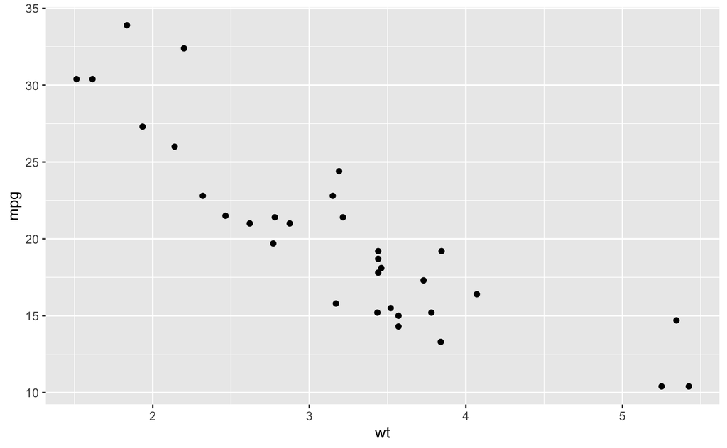

```r
# part (a)
ggplot(data = mtcars, aes(x = wt, y = mpg)) + geom_point()
```

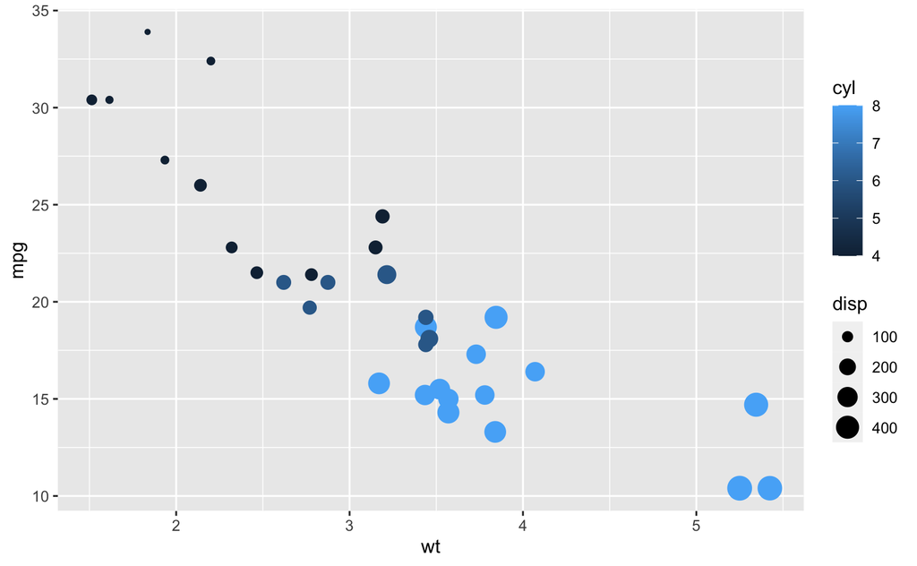

```r
# weight and miles per gallon have an inverse relationship

# part (b)
ggplot(mtcars, aes(x = wt, y = mpg, color = cyl, size = disp)) + geom_point()
```

```r
# part (c)
tapply(mtcars$mpg, mtcars$cyl, sd)
```

```
       4        6        8
4.509828 1.453567 2.560048
```